# Swire EDA

Richard Garbett

2/1/2023

# Business Problem Statement

# Swire Coca-Cola

Predicting Customer Success: Problem Statement

Swire Coca-Cola is a company that provides distribution for soda products in a large area of the United States. A significant amount of their business revenue is driven by local businesses and restaurants, especially when they are first opening. Swire needs to determine if the business or restaurants will be profitable, and if it would be worth it to offer lower prices. It’s essential for Swire to have a good idea of how these businesses will perform so they can offer lower prices and make a profit.

Swire will be able to offer competitive prices to new restaurants and have some reassurance that risk is minimized. Success will include having a predictive model that is accurate in predicting popularity, longevity, and a total 3-year sales volume of new customers. The analytical approach will be using statistical and machine learning techniques to analyze the data set provided.

The scope of the project will include the development of a predictive model that can predict popularity, longevity, and a total 3-year salves volume of new customers, also to pricing and funding decisions. Additional analysis and sources may be added to improve accuracy. This project will be leady by Cole Lifer, Richard Garbett, and Jordan Harmer with a completion date 4/9/2023. Milestones will be gathering data and data cleaning, model development and testing, and implantation of the model in decision-making processes.

# Questions list:

What are the data types? Can any columns be aggregated? What is the target variable? Are there any NAs, if so how many and what columns contain them? What is the correlation between variables? What are the categorical variables and continuous variables? What categorical variables should be mutated into numerical variables? What is the correlation between numerical variables? Are there any variables that seem correlated, but does not show in the data?

# Read data into R and load libraries

# Get a first look into the data.

```
## Rows: 40,386
## Columns: 16
## $ ï..CUSTOMER_NUMBER_BLINDED             <chr> "C0895044502170683", "C04090087~
## $ SALES_OFFICE_DESCRIPTION               <chr> "Tucson, AZ", "Tacoma, WA", "Wa~
## $ DELIVERY_PLANT_DESCRIPTION             <chr> "Tucson, AZ", "Tacoma Sales Cen~
## $ ON_BOARDING_DATE                       <chr> "2017-02-06", "2009-05-11", "20~
## $ ADDRESS_CITY                           <chr> "TUCSON", "FORT LEWIS", "COLLEG~
## $ ADDRESS_ZIP_CODE                       <chr> "85756-6948", "98433", "99324-9~
## $ COUNTY                                 <chr> "PIMA", "PIERCE", "WALLA WALLA"~
## $ GEO_LONGITUDE                          <dbl> -110.9284, -122.5872, -118.3730~
## $ GEO_LATITUDE                           <dbl> 32.11594, 47.10236, 46.05292, 3~
## $ CUSTOMER_ACTIVITY_CLUSTER_DESCRIPTION  <chr> "Other Shopping & Ser", "Eating~
## $ CUSTOMER_TRADE_CHANNEL_DESCRIPTION     <chr> "General Merchandiser", "Quick ~
## $ CUSTOMER_SUB_TRADE_CHANNEL_DESCRIPTION <chr> "Other General Mercha", "QSR-Pi~
## $ BUSINESS_TYPE_EXTENSION_DESCRIPTION    <chr> "DSD", "DSD", "DSD", "DSD", "DS~
## $ CUSTOMER_TRADE_CHANNEL_DESCRIPTION2    <chr> "General Merchandiser", "Quick ~
## $ MARKET_DESCRIPTION                     <chr> "FSOP", "FSOP", "FSOP", "FSOP",~
## $ COLD_DRINK_CHANNEL_DESCRIPTION         <chr> "RETAIL", "EATING/DRINKING", "R~
```

```
## Rows: 831,858
## Columns: 15
## $ ï..CUSTOMER_NUMBER_BLINDED       <chr> "C0051046109640797", "C03480743023804~
## $ PRODUCT_SOLD_BLINDED             <chr> "M056203880974", "M042308250090", "M0~
## $ BEV_CAT_DESC                     <chr> "CORE SPARKLING", "CORE SPARKLING", "~
## $ CALORIE_CAT_DESC                 <chr> "REGULAR CALORIE", "LOW CALORIE", "LO~
## $ PACK_TYPE_DESC                   <chr> "Plastic Bottle - Contour", "Aluminum~
## $ PACK_SIZE_SALES_UNIT_DESCRIPTION <chr> "20 OZ 1-Ls 24", "12 OZ 4-Pk 24", "18~
## $ PHYSICAL_VOLUME                  <dbl> 88.000, 58.000, 108.000, 15.000, 195.~
## $ DISCOUNT                         <dbl> 2246.40, 1197.12, 3429.00, 307.12, 33~
## $ INVOICE_PRICE                    <dbl> 2505.60, 1666.92, 1755.00, 592.88, 20~
## $ DEAD_NET                         <dbl> 1924.70, 1468.77, 1499.03, 553.18, 18~
## $ GROSS_PROFIT_DEAD_NET            <dbl> 1112.73, 316.19, 403.25, 77.90, 661.2~
## $ COGS                             <dbl> 682.41, 1185.98, 1107.73, 475.28, 141~
## $ MIN_POSTING_DATE                 <chr> "1/12/2021", "2/2/2021", "3/7/2022", ~
## $ MAX_POSTING_DATE                 <chr> "12/30/2022", "12/30/2022", "12/30/20~
## $ NUM_OF_TRANSACTIONS              <int> 157, 40, 62, 17, 166, 5, 156, 107, 46~
```

```
##  ï..CUSTOMER_NUMBER_BLINDED SALES_OFFICE_DESCRIPTION DELIVERY_PLANT_DESCRIPTION
##  Length:40386               Length:40386             Length:40386
##  Class :character           Class :character         Class :character
##  Mode  :character           Mode  :character         Mode  :character
##
##
##
##  ON_BOARDING_DATE   ADDRESS_CITY       ADDRESS_ZIP_CODE      COUNTY
##  Length:40386       Length:40386       Length:40386       Length:40386
##  Class :character   Class :character   Class :character   Class :character
##  Mode  :character   Mode  :character   Mode  :character   Mode  :character
##
##
##
##  GEO_LONGITUDE     GEO_LATITUDE   CUSTOMER_ACTIVITY_CLUSTER_DESCRIPTION
##  Min.   :-124.6   Min.   : 0.00   Length:40386
##  1st Qu.:-121.3   1st Qu.:37.42   Class :character
##  Median :-112.1   Median :40.60   Mode  :character
##  Mean   :-114.1   Mean   :40.81
##  3rd Qu.:-111.0   3rd Qu.:45.51
##  Max.   :   0.0   Max.   :49.00
##  CUSTOMER_TRADE_CHANNEL_DESCRIPTION CUSTOMER_SUB_TRADE_CHANNEL_DESCRIPTION
##  Length:40386                       Length:40386
##  Class :character                   Class :character
##  Mode  :character                   Mode  :character
##
##
##
##  BUSINESS_TYPE_EXTENSION_DESCRIPTION CUSTOMER_TRADE_CHANNEL_DESCRIPTION2
##  Length:40386                        Length:40386
##  Class :character                    Class :character
##  Mode  :character                    Mode  :character
##
##
##
##  MARKET_DESCRIPTION COLD_DRINK_CHANNEL_DESCRIPTION
##  Length:40386       Length:40386
##  Class :character   Class :character
##  Mode  :character   Mode  :character
##
##
##
```

```
##  ï..CUSTOMER_NUMBER_BLINDED PRODUCT_SOLD_BLINDED BEV_CAT_DESC
##  Length:831858              Length:831858        Length:831858
##  Class :character           Class :character     Class :character
##  Mode  :character           Mode  :character     Mode  :character
##
##
##
##  CALORIE_CAT_DESC   PACK_TYPE_DESC     PACK_SIZE_SALES_UNIT_DESCRIPTION
##  Length:831858      Length:831858      Length:831858
##  Class :character   Class :character   Class :character
##  Mode  :character   Mode  :character   Mode  :character
##
##
##
##  PHYSICAL_VOLUME        DISCOUNT         INVOICE_PRICE
##  Min.   :-65832.00   Min.   : -13902.0   Min.   : -22982.4
##  1st Qu.:     1.00   1st Qu.:     17.6   1st Qu.:     31.1
##  Median :     5.00   Median :     90.0   Median :    136.8
##  Mean   :    36.22   Mean   :   1003.8   Mean   :    926.5
##  3rd Qu.:    17.00   3rd Qu.:    413.4   3rd Qu.:    523.4
##  Max.   :136349.00   Max.   :2847661.8   Max.   :1813003.8
##     DEAD_NET         GROSS_PROFIT_DEAD_NET      COGS
##  Min.   : -34534.1   Min.   :-145562.4     Min.   :  -7392.3
##  1st Qu.:     29.3   1st Qu.:      8.6     1st Qu.:     12.5
##  Median :    130.0   Median :     44.8     Median :     72.7
##  Mean   :    845.3   Mean   :    295.0     Mean   :    580.3
##  3rd Qu.:    500.0   3rd Qu.:    181.9     3rd Qu.:    297.7
##  Max.   :1813003.8   Max.   : 883618.1     Max.   :1370468.2
##  MIN_POSTING_DATE   MAX_POSTING_DATE   NUM_OF_TRANSACTIONS
##  Length:831858      Length:831858      Min.   :  1.00
##  Class :character   Class :character   1st Qu.:  2.00
##  Mode  :character   Mode  :character   Median :  7.00
##                                        Mean   : 21.23
##                                        3rd Qu.: 24.00
##                                        Max.   :468.00
```

# Are there any N/As in the data set? What columns?

In the Sales data there are two columns that have missing values: BEV_CAT_DESC & CALORIE_CAT_DESC. In the customer attributes data there is one column “County” with two missing values. I will discuss with my group on our approach to deal with them and if we need to at all.

```
##             ï..CUSTOMER_NUMBER_BLINDED               SALES_OFFICE_DESCRIPTION
##                                      0                                      0
##             DELIVERY_PLANT_DESCRIPTION                       ON_BOARDING_DATE
##                                      0                                      0
##                           ADDRESS_CITY                       ADDRESS_ZIP_CODE
##                                      0                                      0
##                                 COUNTY                          GEO_LONGITUDE
##                                      2                                      0
##                           GEO_LATITUDE  CUSTOMER_ACTIVITY_CLUSTER_DESCRIPTION
##                                      0                                      0
##     CUSTOMER_TRADE_CHANNEL_DESCRIPTION CUSTOMER_SUB_TRADE_CHANNEL_DESCRIPTION
##                                      0                                      0
##    BUSINESS_TYPE_EXTENSION_DESCRIPTION    CUSTOMER_TRADE_CHANNEL_DESCRIPTION2
##                                      0                                      0
##                     MARKET_DESCRIPTION         COLD_DRINK_CHANNEL_DESCRIPTION
##                                      0                                      0
```

```
##       ï..CUSTOMER_NUMBER_BLINDED             PRODUCT_SOLD_BLINDED
##                                0                                0
##                     BEV_CAT_DESC                 CALORIE_CAT_DESC
##                            73623                            73623
##                   PACK_TYPE_DESC PACK_SIZE_SALES_UNIT_DESCRIPTION
##                                0                                0
##                  PHYSICAL_VOLUME                         DISCOUNT
##                                0                                0
##                    INVOICE_PRICE                         DEAD_NET
##                                0                                0
##            GROSS_PROFIT_DEAD_NET                             COGS
##                                0                                0
##                 MIN_POSTING_DATE                 MAX_POSTING_DATE
##                                0                                0
##              NUM_OF_TRANSACTIONS
##                                0
```

# Barplots for categorical data

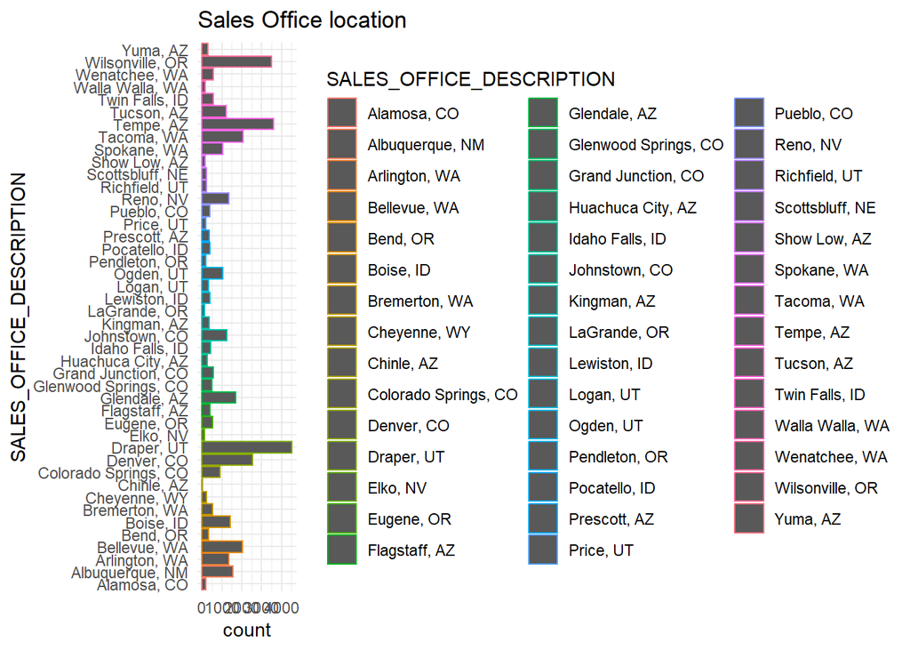

[figure not shown]

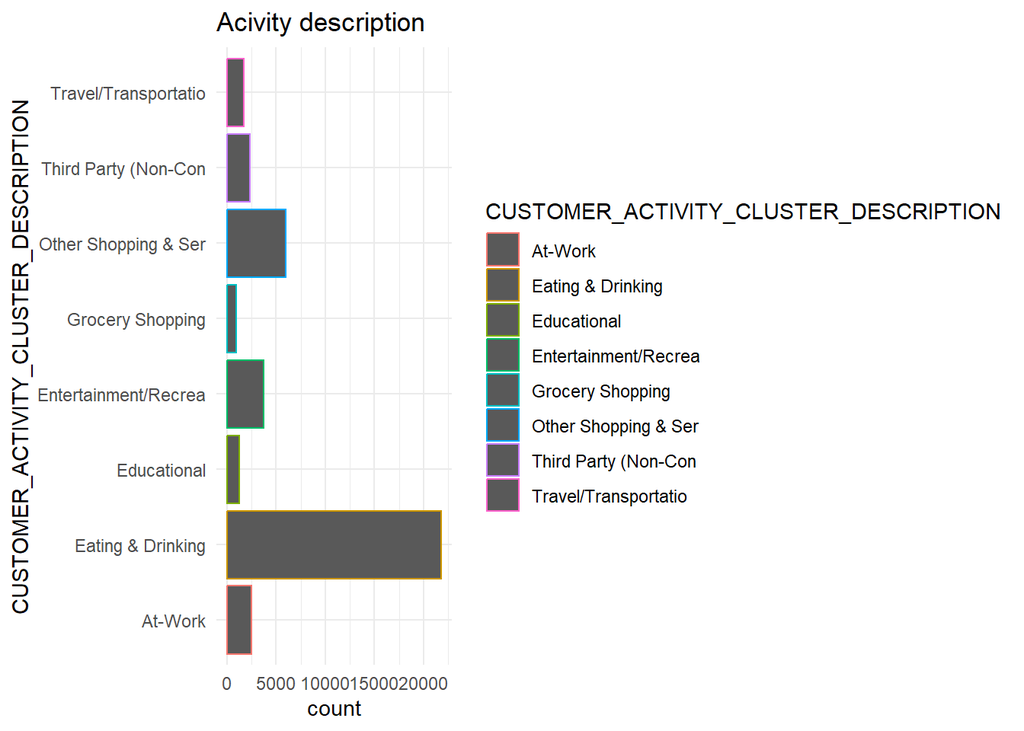

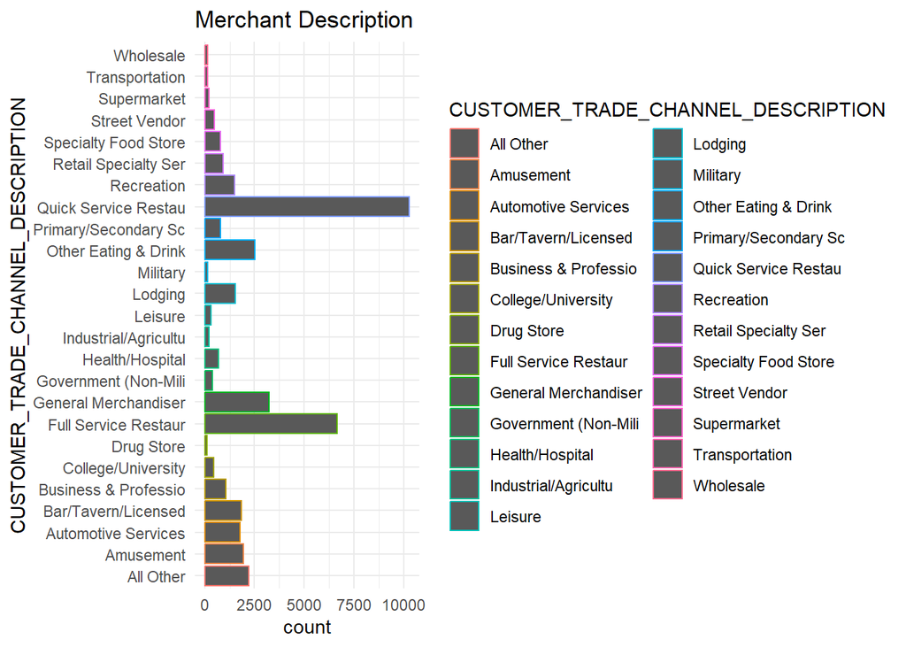

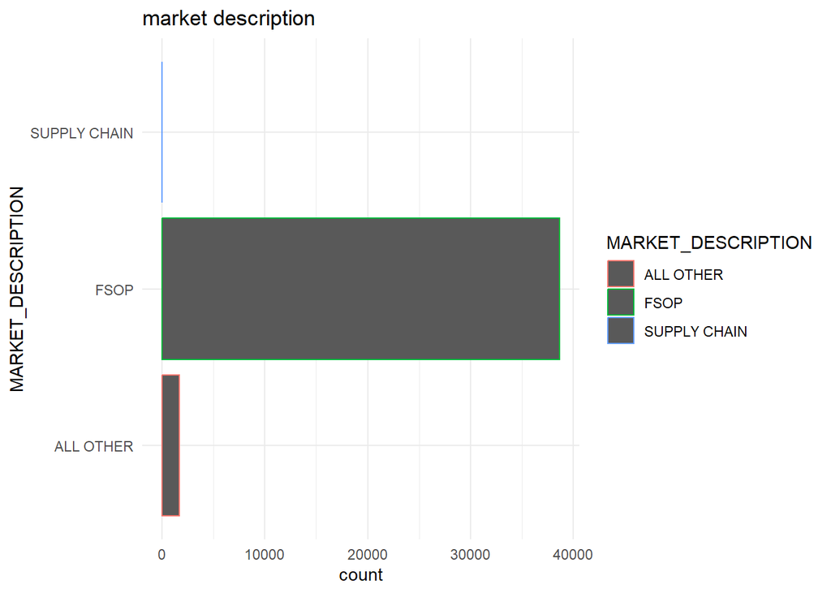

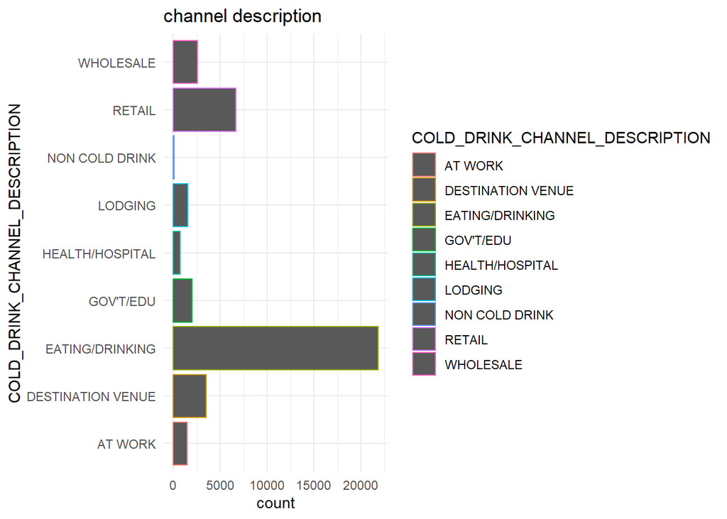

# Bar Plots for Sales data

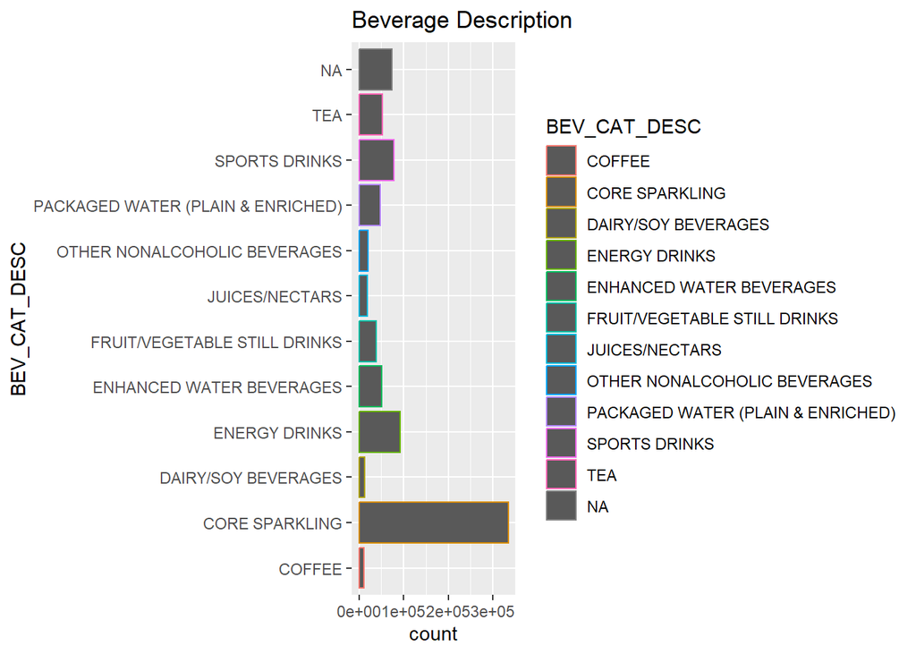

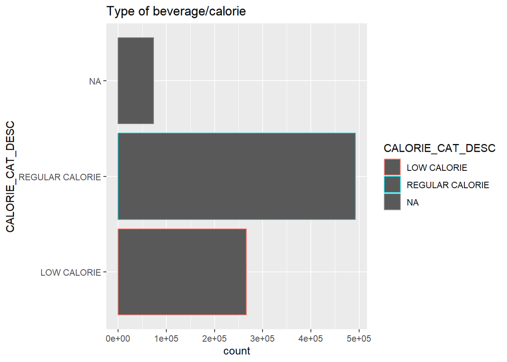

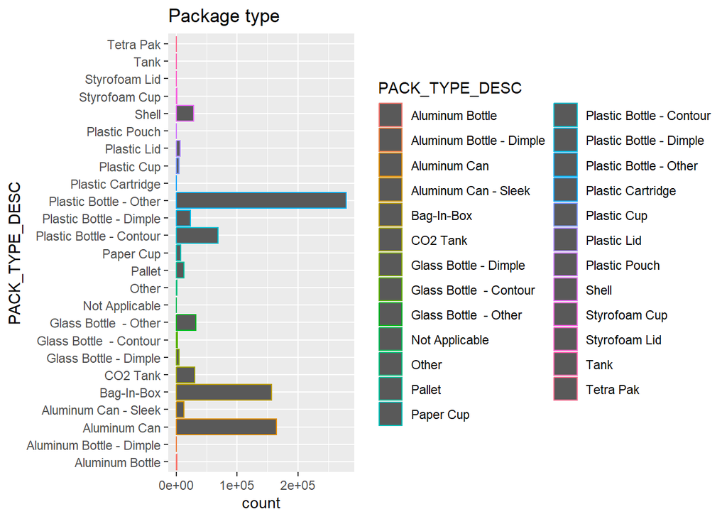

# Correlation plot of numeric vairables in Sales data

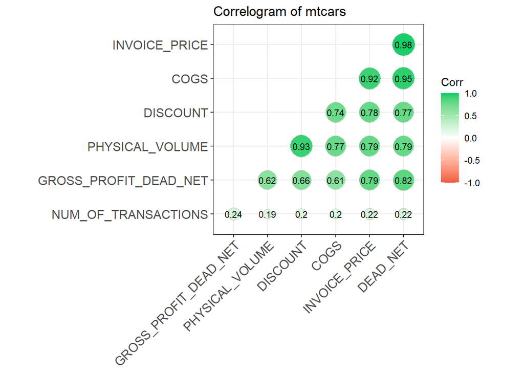